# Assignment 2 Income Classification

```python
# import useful modules
import pandas as pd
import re as regex
import sklearn
import numpy as np
import itertools
from collections import Counter
import matplotlib.pyplot as plt
try:
    from sklearn.model_selection import train_test_split
except:
    from sklearn.cross_validation import train_test_split
try:
    from sklearn.model_selection import GridSearchCV
except:
    from sklearn.grid_search import GridSearchCV
try:
    from sklearn.model_selection import learning_curve
except:
    from sklearn.learning_curve import learning_curve

from sklearn.linear_model import LinearRegression
from sklearn.tree import DecisionTreeClassifier
from sklearn.cross_validation import KFold, cross_val_score
from sklearn.metrics import make_scorer, accuracy_score
from sklearn.feature_extraction.text import CountVectorizer
from sklearn.linear_model import LogisticRegression
from sklearn.ensemble import RandomForestClassifier
from sklearn.neighbors import KNeighborsClassifier
from sklearn.naive_bayes import MultinomialNB
from sklearn.svm import SVC
from sklearn import preprocessing
from sklearn.model_selection import cross_val_predict
from sklearn.metrics import confusion_matrix
from sklearn.ensemble import GradientBoostingClassifier
```

```python
#Import CSV file to open
income_training = pd.read_csv('income-training.csv')
income_training.head(10)
```

|  | Age | WorkClass | FinalWeight | Education | EducationLvl | MaritalStatus | Occupation | Relationship | Race | Sex | CapitalGain | CapitalLoss | HoursPerWeek | NativeCountry | IncomeBracket |
| --- | --- | --- | --- | --- | --- | --- | --- | --- | --- | --- | --- | --- | --- | --- | --- |
| 0 | 42 | State-gov | 179151 | Some-college | 10 | Married-civ-spouse | Farming-fishing | Husband | White | Male | 0 | 0 | 40 | United-States | <50K |
| 1 | 28 | Private | 68021 | Some-college | 10 | Never-married | Other-service | Not-in-family | White | Female | 0 | 0 | 30 | United-States | <50K |
| 2 | 24 | Private | 233499 | Some-college | 10 | Married-civ-spouse | Transport-moving | Husband | White | Male | 0 | 0 | 40 | United-States | 50-100K |
| 3 | 32 | Self-emp-not-inc | 168782 | 9th | 5 | Married-civ-spouse | Craft-repair | Husband | White | Male | 0 | 0 | 32 | United-States | <50K |
| 4 | 55 | Self-emp-not-inc | 105582 | Masters | 14 | Married-civ-spouse | Sales | Husband | White | Male | 2228 | 0 | 50 | United-States | <50K |
| 5 | 35 | Private | 261241 | HS-grad | 9 | Divorced | Transport-moving | Not-in-family | White | Male | 0 | 1741 | 60 | United-States | <50K |
| 6 | 51 | Private | 200576 | Bachelors | 13 | Divorced | Adm-clerical | Not-in-family | White | Female | 0 | 0 | 40 | United-States | <50K |
| 7 | 43 | Self-emp-inc | 175715 | HS-grad | 9 | Never-married | Exec-managerial | Not-in-family | Black | Male | 0 | 0 | 55 | United-States | <50K |
| 8 | 29 | State-gov | 188986 | Assoc-voc | 11 | Never-married | Tech-support | Not-in-family | White | Female | 0 | 1590 | 64 | United-States | <50K |
| 9 | 65 | NaN | 137354 | Some-college | 10 | Married-civ-spouse | NaN | Husband | Asian-Pac-Islander | Male | 0 | 0 | 20 | United-States | <50K |

```python
#Import CSV file to open
income_testing = pd.read_csv('income-testing.csv')
income_testing.head(10)
```

|  | Age | WorkClass | FinalWeight | Education | EducationLvl | MaritalStatus | Occupation | Relationship | Race | Sex | CapitalGain | CapitalLoss | HoursPerWeek | NativeCountry | IncomeBracket |
| --- | --- | --- | --- | --- | --- | --- | --- | --- | --- | --- | --- | --- | --- | --- | --- |
| 0 | 57 | Self-emp-not-inc | 152030 | Some-college | 10 | Married-civ-spouse | Sales | Wife | White | Female | 0 | 0 | 25 | United-States | 50-100K |
| 1 | 35 | Private | 341643 | Bachelors | 13 | Never-married | Other-service | Other-relative | White | Male | 0 | 0 | 50 | United-States | <50K |
| 2 | 26 | Private | 40915 | Bachelors | 13 | Never-married | Other-service | Not-in-family | White | Female | 0 | 0 | 25 | United-States | <50K |
| 3 | 27 | Federal-gov | 257124 | Bachelors | 13 | Never-married | Transport-moving | Other-relative | White | Male | 0 | 0 | 35 | United-States | <50K |
| 4 | 21 | Private | 256278 | HS-grad | 9 | Never-married | Other-service | Other-relative | Other | Female | 0 | 0 | 35 | El-Salvador | <50K |
| 5 | 28 | Private | 128055 | HS-grad | 9 | Married-civ-spouse | Craft-repair | Husband | White | Male | 0 | 0 | 60 | United-States | <50K |
| 6 | 34 | Private | 303187 | Bachelors | 13 | Married-civ-spouse | Prof-specialty | Husband | Asian-Pac-Islander | Male | 0 | 0 | 40 | NaN | >100K |
| 7 | 26 | Private | 205109 | Masters | 14 | Never-married | Prof-specialty | Not-in-family | White | Female | 0 | 0 | 40 | United-States | <50K |
| 8 | 26 | Private | 33610 | HS-grad | 9 | Never-married | Transport-moving | Own-child | White | Male | 0 | 0 | 40 | United-States | <50K |
| 9 | 35 | State-gov | 167482 | HS-grad | 9 | Never-married | Protective-serv | Own-child | White | Male | 0 | 1980 | 40 | United-States | <50K |

## Part 1: Data Cleaning

### a. Missing Value Handling

There are missing values in "WorkClass" and "Occupation" columns, which probably indicate that these people have no occupation. We don't want to delete them because they can actually indicates an income bracket of lower than 5k. We can fill in these missing values with "None".

The missing values in the "Native Country" probably indicate that these people were born in a country other than United-States, Cambodia, England, Puerto-Rico, Canada, Germany, Outlying-US(Guam-USVI-etc), India, Japan, Greece, South, China, Cuba, Iran, Honduras, Philippines, Italy, Poland, Jamaica, Vietnam, Mexico, Portugal, Ireland, France, Dominican-Republic, Laos, Ecuador, Taiwan, Haiti, Columbia, Hungary, Guatemala, Nicaragua, Scotland, Thailand, Yugoslavia, El-Salvador, Trinadad&Tobago, Peru, Hong, Holand-Netherlands. We can fill in theses missing values with "Other".

```python
#filling in missing values
income_training = income_training.fillna({"WorkClass": 'None', "Occupation" : 'None', "NativeCountry" : "Other"})
income_testing = income_testing.fillna({"WorkClass": 'None', "Occupation" : 'None', "NativeCountry" : "Other"})

print("income training dataset with missing values: ",len(income_training[income_training.isnull().any(axis=1)]))
print("income testing dataset with missing values: ", len(income_testing[income_testing.isnull().any(axis=1)]))
```

```
income training dataset with missing values:  0
income testing dataset with missing values:  0
```

### b. Converting Categorical Data to Numerical

Now, as there are no missing values in the data, we can convert categorical data into numerical data.

The 'Education' column is not useful since we have 'Educationlvl' which represents education in continuous data.

We want to use labels encoding for income bracket because these are the target values of model prediction and the increase in label number can actually indicates increase in income. We will represents income lower than 50K as 0, 50-100K as 1, income higher than 100K as 2.

For all the other categorical data we will use one hot encoding. Models assumes that numerical features reflect algebraic quantities, but that is not the case for the categorical data we have here. For example, if we assign male as 0, female as 1, this would imply male < female which doesn't make sense. Thus, we want to use one hot encoding instead of label encoding for the rest of categorical data.

```python
#drop Education column
income_training = income_training.drop('Education', axis=1)
income_testing = income_testing.drop('Education', axis=1)

#label encoding IncomeBracket
cleaned_income_training = income_training
cleaned_income_training['IncomeBracket'] = income_training['IncomeBracket'].map({'<50K': 0, '50-100K': 1, '>100K':2})

cleaned_income_testing = income_testing
cleaned_income_testing['IncomeBracket'] = income_testing['IncomeBracket'].map({'<50K': 0, '50-100K': 1, '>100K':2})

#One-hot encoding of categorical features
cleaned_income_training = pd.get_dummies(cleaned_income_training, columns=["WorkClass"])
cleaned_income_training = pd.get_dummies(cleaned_income_training, columns=["MaritalStatus"])
cleaned_income_training = pd.get_dummies(cleaned_income_training, columns=["Occupation"])
cleaned_income_training = pd.get_dummies(cleaned_income_training, columns=["Relationship"])
cleaned_income_training = pd.get_dummies(cleaned_income_training, columns=["Race"])
cleaned_income_training = pd.get_dummies(cleaned_income_training, columns=["Sex"])
cleaned_income_training = pd.get_dummies(cleaned_income_training, columns=["NativeCountry"])
cleaned_income_training.head(11)
```

|  | Age | FinalWeight | EducationLvl | CapitalGain | CapitalLoss | HoursPerWeek | IncomeBracket | WorkClass_Federal-gov | WorkClass_Local-gov | WorkClass_Never-worked | ... | NativeCountry_Portugal | NativeCountry_Puerto-Rico | NativeCountry_Scotland | NativeCountry_South | NativeCountry_Taiwan | NativeCountry_Thailand | NativeCountry_Trinadad&Tobago | NativeCountry_United-States | NativeCountry_Vietnam | NativeCountry_Yugoslavia |
| --- | --- | --- | --- | --- | --- | --- | --- | --- | --- | --- | --- | --- | --- | --- | --- | --- | --- | --- | --- | --- | --- |
| 0 | 42 | 179151 | 10 | 0 | 0 | 40 | 0 | 0 | 0 | 0 | ... | 0 | 0 | 0 | 0 | 0 | 0 | 0 | 1 | 0 | 0 |
| 1 | 28 | 68021 | 10 | 0 | 0 | 30 | 0 | 0 | 0 | 0 | ... | 0 | 0 | 0 | 0 | 0 | 0 | 0 | 1 | 0 | 0 |
| 2 | 24 | 233499 | 10 | 0 | 0 | 40 | 1 | 0 | 0 | 0 | ... | 0 | 0 | 0 | 0 | 0 | 0 | 0 | 1 | 0 | 0 |
| 3 | 32 | 168782 | 5 | 0 | 0 | 32 | 0 | 0 | 0 | 0 | ... | 0 | 0 | 0 | 0 | 0 | 0 | 0 | 1 | 0 | 0 |
| 4 | 55 | 105582 | 14 | 2228 | 0 | 50 | 0 | 0 | 0 | 0 | ... | 0 | 0 | 0 | 0 | 0 | 0 | 0 | 1 | 0 | 0 |
| 5 | 35 | 261241 | 9 | 0 | 1741 | 60 | 0 | 0 | 0 | 0 | ... | 0 | 0 | 0 | 0 | 0 | 0 | 0 | 1 | 0 | 0 |
| 6 | 51 | 200576 | 13 | 0 | 0 | 40 | 0 | 0 | 0 | 0 | ... | 0 | 0 | 0 | 0 | 0 | 0 | 0 | 1 | 0 | 0 |
| 7 | 43 | 175715 | 9 | 0 | 0 | 55 | 0 | 0 | 0 | 0 | ... | 0 | 0 | 0 | 0 | 0 | 0 | 0 | 1 | 0 | 0 |
| 8 | 29 | 188986 | 11 | 0 | 1590 | 64 | 0 | 0 | 0 | 0 | ... | 0 | 0 | 0 | 0 | 0 | 0 | 0 | 1 | 0 | 0 |
| 9 | 65 | 137354 | 10 | 0 | 0 | 20 | 0 | 0 | 0 | 0 | ... | 0 | 0 | 0 | 0 | 0 | 0 | 0 | 1 | 0 | 0 |
| 10 | 35 | 241998 | 9 | 4787 | 0 | 40 | 2 | 0 | 0 | 0 | ... | 0 | 0 | 0 | 0 | 0 | 0 | 0 | 1 | 0 | 0 |

11 rows × 93 columns

```python
#One-hot encoding of categorical features
cleaned_income_testing = pd.get_dummies(cleaned_income_testing, columns=["WorkClass"])
cleaned_income_testing = pd.get_dummies(cleaned_income_testing, columns=["MaritalStatus"])
cleaned_income_testing = pd.get_dummies(cleaned_income_testing, columns=["Occupation"])
cleaned_income_testing = pd.get_dummies(cleaned_income_testing, columns=["Relationship"])
cleaned_income_testing = pd.get_dummies(cleaned_income_testing, columns=["Race"])
cleaned_income_testing = pd.get_dummies(cleaned_income_testing, columns=["Sex"])
cleaned_income_testing = pd.get_dummies(cleaned_income_testing, columns=["NativeCountry"])
cleaned_income_testing.head(11)
```

|  | Age | FinalWeight | EducationLvl | CapitalGain | CapitalLoss | HoursPerWeek | IncomeBracket | WorkClass_Federal-gov | WorkClass_Local-gov | WorkClass_Never-worked | ... | NativeCountry_Portugal | NativeCountry_Puerto-Rico | NativeCountry_Scotland | NativeCountry_South | NativeCountry_Taiwan | NativeCountry_Thailand | NativeCountry_Trinadad&Tobago | NativeCountry_United-States | NativeCountry_Vietnam | NativeCountry_Yugoslavia |
| --- | --- | --- | --- | --- | --- | --- | --- | --- | --- | --- | --- | --- | --- | --- | --- | --- | --- | --- | --- | --- | --- |
| 0 | 57 | 152030 | 10 | 0 | 0 | 25 | 1 | 0 | 0 | 0 | ... | 0 | 0 | 0 | 0 | 0 | 0 | 0 | 1 | 0 | 0 |
| 1 | 35 | 341643 | 13 | 0 | 0 | 50 | 0 | 0 | 0 | 0 | ... | 0 | 0 | 0 | 0 | 0 | 0 | 0 | 1 | 0 | 0 |
| 2 | 26 | 40915 | 13 | 0 | 0 | 25 | 0 | 0 | 0 | 0 | ... | 0 | 0 | 0 | 0 | 0 | 0 | 0 | 1 | 0 | 0 |
| 3 | 27 | 257124 | 13 | 0 | 0 | 35 | 0 | 1 | 0 | 0 | ... | 0 | 0 | 0 | 0 | 0 | 0 | 0 | 1 | 0 | 0 |
| 4 | 21 | 256278 | 9 | 0 | 0 | 35 | 0 | 0 | 0 | 0 | ... | 0 | 0 | 0 | 0 | 0 | 0 | 0 | 0 | 0 | 0 |
| 5 | 28 | 128055 | 9 | 0 | 0 | 60 | 0 | 0 | 0 | 0 | ... | 0 | 0 | 0 | 0 | 0 | 0 | 0 | 1 | 0 | 0 |
| 6 | 34 | 303187 | 13 | 0 | 0 | 40 | 2 | 0 | 0 | 0 | ... | 0 | 0 | 0 | 0 | 0 | 0 | 0 | 0 | 0 | 0 |
| 7 | 26 | 205109 | 14 | 0 | 0 | 40 | 0 | 0 | 0 | 0 | ... | 0 | 0 | 0 | 0 | 0 | 0 | 0 | 1 | 0 | 0 |
| 8 | 26 | 33610 | 9 | 0 | 0 | 40 | 0 | 0 | 0 | 0 | ... | 0 | 0 | 0 | 0 | 0 | 0 | 0 | 1 | 0 | 0 |
| 9 | 35 | 167482 | 9 | 0 | 1980 | 40 | 0 | 0 | 0 | 0 | ... | 0 | 0 | 0 | 0 | 0 | 0 | 0 | 1 | 0 | 0 |
| 10 | 39 | 166497 | 9 | 0 | 0 | 40 | 1 | 0 | 1 | 0 | ... | 0 | 0 | 0 | 0 | 0 | 0 | 0 | 1 | 0 | 0 |

11 rows × 92 columns

```python
cleaned_income_training.to_csv('cleaned-income-training.csv')
cleaned_income_training.to_csv('cleaned-income-testing.csv')
```

## Part 2: Exploratory data analysis

### a. Order of Feature Importance

We get the order of feature importance by getting the correlation table of the training data.

```python
import seaborn as sns
corr = cleaned_income_training.corr()
```

```python
#sort correlation table in descending order based on correlation with Income Bracket
SortedCorr = corr.sort_values(by=['IncomeBracket'], ascending=False)
SortedCorr.to_csv('sorted_correlation.csv')
SortedCorr
```

|  | Age | FinalWeight | EducationLvl | CapitalGain | CapitalLoss | HoursPerWeek | IncomeBracket | WorkClass_Federal-gov | WorkClass_Local-gov | WorkClass_Never-worked | ... | NativeCountry_Portugal | NativeCountry_Puerto-Rico | NativeCountry_Scotland | NativeCountry_South | NativeCountry_Taiwan | NativeCountry_Thailand | NativeCountry_Trinadad&Tobago | NativeCountry_United-States | NativeCountry_Vietnam | NativeCountry_Yugoslavia |
| --- | --- | --- | --- | --- | --- | --- | --- | --- | --- | --- | --- | --- | --- | --- | --- | --- | --- | --- | --- | --- | --- |
| IncomeBracket | 0.215345 | -0.008547 | 0.312047 | 0.206740 | 0.138674 | 0.216781 | 1.000000 | 0.065369 | 0.037045 | -0.008276 | ... | -0.009603 | -0.014644 | -0.004973 | -0.009453 | -0.002103 | 0.000260 | -0.006449 | 0.036259 | -0.015862 | 0.012224 |
| MaritalStatus_Married-civ-spouse | 0.308514 | -0.024625 | 0.087877 | 0.079651 | 0.077519 | 0.209177 | 0.419146 | 0.016188 | 0.010382 | -0.014523 | ... | 0.011196 | -0.006191 | 0.003560 | 0.002046 | 0.003881 | -0.003076 | 0.003546 | -0.007305 | -0.005603 | 0.015558 |
| Relationship_Husband | 0.310252 | -0.020509 | 0.082870 | 0.075072 | 0.071536 | 0.244027 | 0.378773 | 0.018723 | -0.000805 | -0.012966 | ... | 0.010117 | -0.010401 | -0.001840 | -0.007811 | 0.000954 | -0.007044 | -0.001015 | 0.010383 | -0.002917 | 0.018507 |
| EducationLvl | 0.040821 | -0.040947 | 1.000000 | 0.131804 | 0.079319 | 0.144161 | 0.312047 | 0.061958 | 0.097762 | -0.017824 | ... | -0.043320 | -0.032482 | 0.006657 | 0.019628 | 0.039182 | 0.012491 | -0.013281 | 0.103125 | 0.002157 | -0.005571 |
| HoursPerWeek | 0.069133 | -0.015199 | 0.144161 | 0.089706 | 0.055957 | 1.000000 | 0.216781 | 0.016129 | 0.008650 | -0.015632 | ... | 0.007039 | -0.010854 | 0.004613 | 0.010429 | -0.008312 | 0.005691 | -0.007530 | 0.007298 | -0.001051 | 0.004990 |
| Age | 1.000000 | -0.085118 | 0.040821 | 0.075229 | 0.059132 | 0.069133 | 0.215345 | 0.052812 | 0.062365 | -0.022728 | ... | 0.007023 | 0.001822 | 0.011023 | 0.000995 | -0.013699 | -0.000185 | 0.000096 | 0.011071 | -0.004885 | 0.008530 |
| CapitalGain | 0.075229 | -0.005131 | 0.131804 | 1.000000 | -0.032197 | 0.089706 | 0.206740 | -0.003473 | -0.005694 | -0.002283 | ... | -0.004187 | -0.004894 | -0.001736 | 0.001791 | 0.011889 | -0.003611 | -0.002606 | 0.001214 | -0.000168 | 0.000357 |
| Sex_Male | 0.084536 | 0.034786 | 0.014817 | 0.045600 | 0.052090 | 0.225756 | 0.203177 | 0.006266 | -0.038030 | 0.005451 | ... | -0.000221 | -0.009026 | -0.001509 | -0.010461 | -0.001867 | -0.010708 | -0.010220 | -0.004845 | 0.000413 | 0.009541 |
| Occupation_Exec-managerial | 0.099615 | -0.009311 | 0.201456 | 0.057008 | 0.054033 | 0.133811 | 0.198241 | 0.029646 | -0.023503 | -0.005980 | ... | -0.008990 | -0.011023 | 0.003493 | 0.009177 | 0.003669 | 0.010396 | -0.003472 | 0.030456 | -0.010154 | 0.021688 |
| Occupation_Prof-specialty | 0.057287 | -0.013980 | 0.416608 | 0.091966 | 0.041768 | 0.063283 | 0.179840 | 0.037765 | 0.169964 | -0.005976 | ... | -0.012683 | -0.004915 | -0.002295 | 0.001617 | 0.034779 | -0.004486 | -0.008798 | -0.011884 | -0.010143 | -0.009131 |
| CapitalLoss | 0.059132 | 0.002625 | 0.079319 | -0.032197 | 1.000000 | 0.055957 | 0.138674 | 0.003048 | 0.010869 | -0.003465 | ... | -0.007354 | 0.007620 | -0.004693 | -0.003628 | -0.003392 | 0.000500 | -0.005102 | 0.013804 | 0.004635 | -0.005294 |
| WorkClass_Self-emp-inc | 0.095619 | -0.020817 | 0.085027 | 0.105063 | 0.038122 | 0.129226 | 0.134744 | -0.032788 | -0.049661 | -0.002966 | ... | 0.007197 | -0.007808 | -0.004016 | 0.009190 | 0.005847 | 0.013406 | -0.004366 | -0.005655 | -0.002599 | 0.004834 |
| Relationship_Wife | 0.018185 | -0.015245 | 0.030779 | 0.018061 | 0.016062 | -0.065683 | 0.110242 | -0.000589 | 0.026931 | -0.003539 | ... | 0.003964 | 0.011442 | 0.013178 | 0.020320 | 0.008016 | 0.009794 | 0.011321 | -0.016874 | -0.004933 | -0.005406 |
| Race_White | 0.032227 | -0.068477 | 0.043445 | 0.012203 | 0.019450 | 0.049250 | 0.080600 | -0.040676 | -0.031229 | -0.008470 | ... | 0.010121 | -0.019378 | 0.008699 | -0.116674 | -0.083726 | -0.046369 | -0.056321 | 0.195173 | -0.096926 | 0.009814 |
| WorkClass_Federal-gov | 0.052812 | -0.016390 | 0.061958 | -0.003473 | 0.003048 | 0.016129 | 0.065369 | 1.000000 | -0.045485 | -0.002717 | ... | -0.005765 | 0.013560 | -0.003679 | 0.001545 | -0.006178 | -0.004296 | 0.006553 | 0.016407 | -0.001473 | -0.004150 |
| WorkClass_Local-gov | 0.062365 | -0.002554 | 0.097762 | -0.005694 | 0.010869 | 0.008650 | 0.037045 | -0.045485 | 1.000000 | -0.004115 | ... | -0.003714 | 0.003300 | -0.005572 | -0.012807 | -0.004674 | 0.000224 | 0.008402 | 0.034712 | 0.000909 | -0.006286 |
| NativeCountry_United-States | 0.011071 | -0.071810 | 0.103125 | 0.001214 | 0.013804 | 0.007298 | 0.036259 | 0.016407 | 0.034712 | 0.005227 | ... | -0.099787 | -0.182420 | -0.063671 | -0.146346 | -0.106932 | -0.074358 | -0.069221 | 1.000000 | -0.125970 | -0.071836 |
| Occupation_Protective-serv | 0.007388 | 0.010028 | -0.002405 | -0.006684 | -0.005709 | 0.019380 | 0.026735 | 0.008777 | 0.225921 | -0.002220 | ... | -0.004711 | -0.008612 | 0.010897 | -0.006909 | -0.005048 | -0.003510 | 0.009521 | 0.021646 | -0.005947 | -0.003391 |
| WorkClass_Self-emp-not-inc | 0.144547 | -0.043217 | 0.014474 | 0.027923 | 0.016327 | 0.080400 | 0.026040 | -0.050478 | -0.076455 | -0.004566 | ... | -0.000513 | -0.010165 | 0.001004 | 0.029651 | -0.010385 | -0.001066 | -0.000111 | 0.017825 | 0.002317 | -0.000605 |
| Occupation_Tech-support | -0.014828 | -0.005651 | 0.059336 | -0.008870 | 0.001818 | -0.004868 | 0.021730 | 0.045837 | -0.015347 | -0.002738 | ... | -0.005811 | -0.010623 | -0.003708 | -0.008522 | 0.007343 | -0.004330 | -0.004031 | 0.016366 | 0.009951 | -0.004183 |
| Occupation_Sales | -0.024386 | 0.003559 | 0.035868 | 0.005102 | 0.004159 | 0.020194 | 0.019303 | -0.054637 | -0.089571 | -0.005571 | ... | -0.000106 | -0.008761 | -0.001427 | 0.011991 | -0.005379 | -0.003571 | -0.008201 | 0.030668 | -0.005637 | -0.008511 |
| NativeCountry_Canada | 0.031350 | -0.003272 | 0.015583 | 0.007879 | 0.011305 | -0.000379 | 0.018520 | 0.002563 | -0.003705 | -0.000910 | ... | -0.001931 | -0.003530 | -0.001232 | -0.002832 | -0.002069 | -0.001439 | -0.001340 | -0.174096 | -0.002438 | -0.001390 |
| NativeCountry_India | -0.004030 | -0.008923 | 0.054861 | 0.017015 | 0.005315 | -0.003286 | 0.018342 | -0.000572 | -0.008263 | -0.000858 | ... | -0.001822 | -0.003330 | -0.001162 | -0.002672 | -0.001952 | -0.001357 | -0.001264 | -0.164234 | -0.002300 | -0.001311 |
| NativeCountry_Cambodia | -0.004063 | 0.008146 | -0.013281 | -0.002276 | 0.010379 | 0.004388 | 0.016490 | -0.003999 | -0.006057 | -0.000362 | ... | -0.000768 | -0.001404 | -0.000490 | -0.001126 | -0.000823 | -0.000572 | -0.000533 | -0.069221 | -0.000969 | -0.000553 |
| NativeCountry_Ireland | 0.001068 | -0.009213 | -0.000513 | -0.001968 | -0.000185 | 0.007435 | 0.013734 | -0.004836 | -0.007324 | -0.000437 | ... | -0.000928 | -0.001697 | -0.000592 | -0.001361 | -0.000995 | -0.000692 | -0.000644 | -0.083694 | -0.001172 | -0.000668 |
| NativeCountry_Japan | -0.001398 | 0.006629 | 0.022474 | 0.012632 | -0.005944 | 0.004905 | 0.013675 | -0.001915 | -0.011402 | -0.000681 | ... | -0.001445 | -0.002642 | -0.000922 | -0.002120 | -0.001549 | -0.001077 | -0.001003 | -0.130298 | -0.001824 | -0.001040 |
| NativeCountry_Greece | 0.018213 | -0.013522 | -0.006286 | 0.000616 | 0.006180 | 0.023594 | 0.012757 | -0.006178 | -0.009358 | -0.000559 | ... | -0.001186 | -0.002168 | -0.000757 | -0.001739 | -0.001271 | -0.000884 | -0.000823 | -0.106932 | -0.001497 | -0.000854 |
| WorkClass_State-gov | 0.013635 | -0.021399 | 0.106703 | -0.007451 | -0.004268 | -0.018978 | 0.012596 | -0.035395 | -0.053611 | -0.003202 | ... | -0.006795 | -0.012422 | 0.005507 | -0.009966 | 0.016180 | 0.003366 | 0.004340 | 0.025639 | -0.003597 | -0.004892 |
| NativeCountry_Yugoslavia | 0.008530 | 0.006164 | -0.005571 | 0.000357 | -0.005294 | 0.004990 | 0.012224 | -0.004150 | -0.006286 | -0.000375 | ... | -0.000797 | -0.001457 | -0.000508 | -0.001169 | -0.000854 | -0.000594 | -0.000553 | -0.071836 | -0.001006 | 1.000000 |
| NativeCountry_China | 0.015759 | -0.011308 | 0.033978 | -0.001508 | 0.006498 | -0.004483 | 0.012025 | 0.001869 | -0.009097 | -0.000752 | ... | -0.001595 | -0.002916 | -0.001018 | -0.002339 | -0.001709 | -0.001189 | -0.001106 | -0.143795 | -0.002013 | -0.001148 |
| ... | ... | ... | ... | ... | ... | ... | ... | ... | ... | ... | ... | ... | ... | ... | ... | ... | ... | ... | ... | ... | ... |
| NativeCountry_Columbia | 0.004372 | 0.012737 | -0.011489 | -0.004817 | -0.000086 | 0.003706 | -0.014488 | -0.006931 | -0.006321 | -0.000627 | ... | -0.001331 | -0.002432 | -0.000849 | -0.001951 | -0.001426 | -0.000992 | -0.000923 | -0.119958 | -0.001680 | -0.000958 |
| NativeCountry_Puerto-Rico | 0.001822 | 0.005072 | -0.032482 | -0.004894 | 0.007620 | -0.010854 | -0.014644 | 0.013560 | 0.003300 | -0.000953 | ... | -0.002023 | 1.000000 | -0.001291 | -0.002967 | -0.002168 | -0.001508 | -0.001404 | -0.182420 | -0.002554 | -0.001457 |
| NativeCountry_Nicaragua | -0.006257 | 0.035561 | -0.011098 | -0.004170 | -0.000821 | -0.005431 | -0.015114 | 0.003547 | -0.007514 | -0.000449 | ... | -0.000952 | -0.001741 | -0.000608 | -0.001397 | -0.001021 | -0.000710 | -0.000661 | -0.085870 | -0.001202 | -0.000686 |
| Occupation_Craft-repair | 0.008454 | 0.013930 | -0.149370 | -0.023434 | -0.009347 | 0.053981 | -0.015741 | -0.036215 | -0.040967 | -0.005936 | ... | 0.013450 | -0.002621 | -0.008038 | -0.003232 | -0.010026 | -0.004396 | 0.001984 | 0.001777 | 0.010643 | 0.001264 |
| NativeCountry_Vietnam | -0.004885 | -0.008603 | 0.002157 | -0.000168 | 0.004635 | -0.001051 | -0.015862 | -0.001473 | 0.000909 | -0.000658 | ... | -0.001397 | -0.002554 | -0.000892 | -0.002049 | -0.001497 | -0.001041 | -0.000969 | -0.125970 | 1.000000 | -0.001006 |
| NativeCountry_Dominican-Republic | 0.000286 | 0.004615 | -0.044314 | 0.007345 | 0.000066 | 0.010481 | -0.017750 | -0.007362 | -0.003287 | -0.000666 | ... | -0.001413 | -0.002584 | -0.000902 | -0.002073 | -0.001515 | -0.001053 | -0.000980 | -0.127429 | -0.001784 | -0.001018 |
| NativeCountry_Guatemala | -0.024457 | 0.029329 | -0.062653 | -0.004734 | -0.009392 | -0.008731 | -0.019310 | -0.001623 | -0.003287 | -0.000666 | ... | -0.001413 | -0.002584 | -0.000902 | -0.002073 | -0.001515 | -0.001053 | -0.000980 | -0.127429 | -0.001784 | -0.001018 |
| NativeCountry_El-Salvador | -0.023181 | 0.041788 | -0.079721 | -0.006096 | -0.006915 | -0.016788 | -0.024478 | -0.009935 | -0.012129 | -0.000899 | ... | -0.001907 | -0.003487 | -0.001217 | -0.002797 | -0.002044 | -0.001421 | -0.001323 | -0.171952 | -0.002408 | -0.001373 |
| Race_Amer-Indian-Eskimo | -0.021696 | -0.072581 | -0.029300 | -0.009075 | -0.010721 | 0.003181 | -0.028717 | 0.018494 | 0.036750 | -0.001525 | ... | -0.003237 | -0.005917 | -0.002065 | 0.012710 | -0.003469 | -0.002412 | -0.002245 | 0.022526 | -0.004086 | -0.002330 |
| MaritalStatus_Married-spouse-absent | 0.014368 | 0.006598 | -0.031304 | -0.002673 | -0.006452 | -0.003234 | -0.033480 | 0.004762 | -0.009836 | -0.001757 | ... | -0.003729 | 0.017602 | -0.002379 | 0.002131 | 0.016783 | -0.002779 | -0.002587 | -0.094547 | 0.012939 | -0.002684 |
| Occupation_Priv-house-serv | 0.022025 | 0.009532 | -0.077089 | -0.009599 | -0.010269 | -0.041459 | -0.035347 | -0.011920 | -0.018054 | -0.001078 | ... | -0.002288 | -0.004183 | -0.001460 | -0.003356 | -0.002452 | -0.001705 | -0.001587 | -0.058798 | -0.002889 | -0.001647 |
| Occupation_Farming-fishing | 0.036383 | -0.029382 | -0.106662 | -0.003951 | -0.012131 | 0.083216 | -0.048838 | -0.024193 | -0.022591 | -0.002713 | ... | 0.008911 | 0.009586 | -0.003673 | -0.008443 | -0.006169 | -0.004290 | -0.003994 | -0.021910 | 0.004359 | 0.006038 |
| NativeCountry_Mexico | -0.054991 | 0.131520 | -0.230431 | -0.016121 | -0.018569 | -0.005134 | -0.059978 | -0.019434 | -0.024215 | -0.002231 | ... | -0.004736 | -0.008657 | -0.003022 | -0.006945 | -0.005075 | -0.003529 | -0.003285 | -0.426950 | -0.005978 | -0.003409 |
| MaritalStatus_Widowed | 0.276057 | -0.026042 | -0.062649 | -0.009006 | -0.003107 | -0.105622 | -0.061392 | 0.002624 | 0.022179 | -0.002808 | ... | 0.008243 | 0.008578 | -0.003802 | 0.005805 | -0.006385 | -0.004440 | -0.004133 | 0.006235 | -0.007522 | 0.005569 |
| MaritalStatus_Separated | 0.015886 | 0.021644 | -0.062931 | -0.010194 | -0.013208 | -0.012637 | -0.068427 | -0.006755 | -0.003047 | -0.002785 | ... | 0.001246 | 0.024515 | 0.007436 | -0.008667 | -0.006333 | -0.004404 | -0.004099 | -0.019236 | -0.007460 | -0.004254 |
| Occupation_Machine-op-inspct | -0.022349 | 0.013478 | -0.156521 | -0.027082 | -0.012387 | 0.006823 | -0.071627 | -0.036204 | -0.056701 | -0.004009 | ... | 0.022293 | 0.012601 | 0.002611 | -0.008973 | -0.009117 | 0.000546 | 0.001494 | -0.048922 | 0.001467 | 0.008130 |
| Relationship_Other-relative | -0.068240 | 0.017226 | -0.092021 | -0.020577 | -0.018477 | -0.050016 | -0.076738 | -0.016281 | -0.021836 | -0.002762 | ... | -0.005861 | 0.013018 | -0.003739 | 0.011100 | -0.006280 | 0.005306 | 0.006325 | -0.113003 | 0.026902 | -0.004219 |
| WorkClass_None | 0.028860 | -0.004360 | -0.080969 | -0.016780 | -0.011102 | -0.171230 | -0.076764 | -0.042475 | -0.064334 | -0.003842 | ... | 0.002504 | -0.011985 | 0.003143 | 0.009871 | 0.011157 | 0.001072 | -0.005657 | 0.004398 | -0.001846 | -0.005870 |
| Occupation_None | 0.027264 | -0.003962 | -0.082010 | -0.016901 | -0.011314 | -0.171940 | -0.077168 | -0.042573 | -0.064482 | 0.063811 | ... | 0.002463 | -0.012025 | 0.003114 | 0.009799 | 0.011097 | 0.001043 | -0.005670 | 0.004742 | -0.001886 | -0.005884 |
| WorkClass_Private | -0.195320 | 0.052112 | -0.120984 | -0.041970 | -0.024266 | -0.013518 | -0.078824 | -0.262338 | -0.397343 | -0.023731 | ... | 0.003222 | 0.013727 | 0.001434 | -0.015328 | -0.003957 | -0.005186 | -0.004056 | -0.046047 | 0.002258 | 0.008381 |
| Occupation_Adm-clerical | -0.044767 | 0.008851 | 0.004038 | -0.030368 | -0.023583 | -0.082362 | -0.080128 | 0.117353 | 0.013750 | -0.005679 | ... | -0.004356 | 0.018062 | 0.004363 | -0.004540 | -0.005732 | 0.001341 | 0.019358 | 0.024890 | 0.012236 | -0.008676 |
| Occupation_Handlers-cleaners | -0.092662 | 0.017856 | -0.126796 | -0.022114 | -0.014664 | -0.041574 | -0.081433 | -0.015470 | -0.028166 | -0.003343 | ... | -0.001052 | -0.006341 | -0.004526 | -0.006279 | -0.007602 | -0.005286 | -0.004921 | -0.015230 | 0.000623 | -0.005107 |
| Race_Black | -0.015090 | 0.134602 | -0.069973 | -0.022307 | -0.021265 | -0.051674 | -0.087199 | 0.035464 | 0.038192 | 0.012664 | ... | -0.010823 | -0.010596 | -0.006906 | -0.015872 | -0.011598 | -0.002446 | 0.052840 | 0.015674 | -0.013662 | -0.007791 |
| MaritalStatus_Divorced | 0.129974 | -0.022678 | -0.006775 | -0.013502 | -0.022256 | 0.030101 | -0.125100 | 0.006343 | 0.032486 | 0.001454 | ... | -0.005929 | -0.004246 | -0.002737 | -0.006963 | -0.010716 | -0.000118 | -0.003920 | 0.046619 | 0.000562 | -0.004454 |
| Relationship_Unmarried | 0.046937 | 0.004130 | -0.055490 | -0.029735 | -0.036169 | -0.032093 | -0.139431 | 0.012434 | 0.035756 | -0.005354 | ... | -0.003305 | 0.021208 | -0.000940 | 0.002589 | -0.000896 | 0.007744 | 0.003726 | -0.021777 | 0.011203 | -0.008180 |
| Occupation_Other-service | -0.093300 | -0.013302 | -0.162807 | -0.037854 | -0.039102 | -0.151438 | -0.144542 | -0.034357 | -0.005465 | -0.005234 | ... | 0.001199 | 0.020190 | 0.005762 | 0.008916 | -0.008074 | 0.008230 | 0.010025 | -0.046801 | 0.005488 | 0.003395 |
| Relationship_Not-in-family | -0.006629 | 0.000900 | 0.051046 | -0.021479 | -0.017059 | 0.008044 | -0.178100 | 0.011557 | 0.001875 | -0.003252 | ... | -0.008311 | -0.003343 | 0.005160 | -0.011405 | -0.002573 | -0.007033 | -0.001404 | 0.022080 | -0.009085 | -0.002360 |
| Sex_Female | -0.084536 | -0.034786 | -0.014817 | -0.045600 | -0.052090 | -0.225756 | -0.203177 | -0.006266 | 0.038030 | -0.005451 | ... | 0.000221 | 0.009026 | 0.001509 | 0.010461 | 0.001867 | 0.010708 | 0.010220 | 0.004845 | -0.000413 | -0.009541 |
| Relationship_Own-child | -0.433107 | 0.024273 | -0.102486 | -0.052027 | -0.046912 | -0.252231 | -0.211132 | -0.042020 | -0.037223 | 0.029578 | ... | -0.000484 | -0.012762 | -0.009036 | 0.004910 | 0.000781 | 0.003206 | -0.009824 | 0.041180 | -0.004325 | -0.010195 |
| MaritalStatus_Never-married | -0.532183 | 0.042933 | -0.034793 | -0.067981 | -0.058224 | -0.199250 | -0.298394 | -0.021647 | -0.038984 | 0.016858 | ... | -0.010141 | -0.006546 | -0.002513 | 0.003506 | 0.004462 | 0.007303 | 0.002766 | 0.000318 | 0.008074 | -0.013102 |

93 rows × 93 columns

```python
SortedCorr['IncomeBracket'].head(20)
```

```
IncomeBracket                       1.000000
MaritalStatus_Married-civ-spouse    0.419146
Relationship_Husband                0.378773
EducationLvl                        0.312047
HoursPerWeek                        0.216781
Age                                 0.215345
CapitalGain                         0.206740
Sex_Male                            0.203177
Occupation_Exec-managerial          0.198241
Occupation_Prof-specialty           0.179840
CapitalLoss                         0.138674
WorkClass_Self-emp-inc              0.134744
Relationship_Wife                   0.110242
Race_White                          0.080600
WorkClass_Federal-gov               0.065369
WorkClass_Local-gov                 0.037045
NativeCountry_United-States         0.036259
Occupation_Protective-serv          0.026735
WorkClass_Self-emp-not-inc          0.026040
Occupation_Tech-support             0.021730
Name: IncomeBracket, dtype: float64
```

Since the correlation table is too big, we will only plot the top 20 related features. You can see the sorted correlation table in sorted_correction.csv file. EducationLvl, HoursePerWeek, Age, CapitalGain and CapitalLoss are the original attributes that are 5 most related to an individual's income bracket. On the other hand, MaritalStatus_Married-civ-spouse, Relationship_Husband, Sex_Male, Occupation_Exec-managerial, Occupation_Prof-specialty are 5 most related features to income bracket that were created based on the original features.

```python
top20corr = pd.DataFrame(data = corr, index=['IncomeBracket', 'MaritalStatus_Married-civ-spouse', 'Relationship_Husband', 'EducationLvl', 'HoursPerWeek', 'Age', 'CapitalGain', 'Sex_Male', 'Occupation_Exec-managerial', 'Occupation_Prof-specialty', 'CapitalLoss', 'WorkClass_Self-emp-inc', 'Relationship_Wife', 'Race_White', 'WorkClass_Federal-gov', 'WorkClass_Local-gov', 'NativeCountry_United-States', 'Occupation_Protective-serv', 'WorkClass_Self-emp-not-inc', 'Occupation_Tech-support'], columns=['IncomeBracket', 'MaritalStatus_Married-civ-spouse', 'Relationship_Husband', 'EducationLvl', 'HoursPerWeek', 'Age', 'CapitalGain', 'Sex_Male', 'Occupation_Exec-managerial', 'Occupation_Prof-specialty', 'CapitalLoss', 'WorkClass_Self-emp-inc', 'Relationship_Wife', 'Race_White', 'WorkClass_Federal-gov', 'WorkClass_Local-gov', 'NativeCountry_United-States', 'Occupation_Protective-serv', 'WorkClass_Self-emp-not-inc', 'Occupation_Tech-support'])
top20corr
```

|  | IncomeBracket | MaritalStatus_Married-civ-spouse | Relationship_Husband | EducationLvl | HoursPerWeek | Age | CapitalGain | Sex_Male | Occupation_Exec-managerial | Occupation_Prof-specialty | CapitalLoss | WorkClass_Self-emp-inc | Relationship_Wife | Race_White | WorkClass_Federal-gov | WorkClass_Local-gov | NativeCountry_United-States | Occupation_Protective-serv | WorkClass_Self-emp-not-inc | Occupation_Tech-support |
| --- | --- | --- | --- | --- | --- | --- | --- | --- | --- | --- | --- | --- | --- | --- | --- | --- | --- | --- | --- | --- |
| IncomeBracket | 1.000000 | 0.419146 | 0.378773 | 0.312047 | 0.216781 | 0.215345 | 0.206740 | 0.203177 | 0.198241 | 0.179840 | 0.138674 | 0.134744 | 0.110242 | 0.080600 | 0.065369 | 0.037045 | 0.036259 | 0.026735 | 0.026040 | 0.021730 |
| MaritalStatus_Married-civ-spouse | 0.419146 | 1.000000 | 0.891625 | 0.087877 | 0.209177 | 0.308514 | 0.079651 | 0.429538 | 0.097755 | 0.048539 | 0.077519 | 0.105756 | 0.239834 | 0.106418 | 0.016188 | 0.010382 | -0.007305 | 0.031543 | 0.114669 | -0.009170 |
| Relationship_Husband | 0.378773 | 0.891625 | 1.000000 | 0.082870 | 0.244027 | 0.310252 | 0.075072 | 0.580561 | 0.094130 | 0.034107 | 0.071536 | 0.114186 | -0.186699 | 0.118866 | 0.018723 | -0.000805 | 0.010383 | 0.042658 | 0.116180 | -0.010669 |
| EducationLvl | 0.312047 | 0.087877 | 0.082870 | 1.000000 | 0.144161 | 0.040821 | 0.131804 | 0.014817 | 0.201456 | 0.416608 | 0.079319 | 0.085027 | 0.030779 | 0.043445 | 0.061958 | 0.097762 | 0.103125 | -0.002405 | 0.014474 | 0.059336 |
| HoursPerWeek | 0.216781 | 0.209177 | 0.244027 | 0.144161 | 1.000000 | 0.069133 | 0.089706 | 0.225756 | 0.133811 | 0.063283 | 0.055957 | 0.129226 | -0.065683 | 0.049250 | 0.016129 | 0.008650 | 0.007298 | 0.019380 | 0.080400 | -0.004868 |
| Age | 0.215345 | 0.308514 | 0.310252 | 0.040821 | 0.069133 | 1.000000 | 0.075229 | 0.084536 | 0.099615 | 0.057287 | 0.059132 | 0.095619 | 0.018185 | 0.032227 | 0.052812 | 0.062365 | 0.011071 | 0.007388 | 0.144547 | -0.014828 |
| CapitalGain | 0.206740 | 0.079651 | 0.075072 | 0.131804 | 0.089706 | 0.075229 | 1.000000 | 0.045600 | 0.057008 | 0.091966 | -0.032197 | 0.105063 | 0.018061 | 0.012203 | -0.003473 | -0.005694 | 0.001214 | -0.006684 | 0.027923 | -0.008870 |
| Sex_Male | 0.203177 | 0.429538 | 0.580561 | 0.014817 | 0.225756 | 0.084536 | 0.045600 | 1.000000 | 0.031980 | -0.021368 | 0.052090 | 0.085656 | -0.320270 | 0.101163 | 0.006266 | -0.038030 | -0.004845 | 0.059903 | 0.102375 | -0.024278 |
| Occupation_Exec-managerial | 0.198241 | 0.097755 | 0.094130 | 0.201456 | 0.133811 | 0.099615 | 0.057008 | 0.031980 | 1.000000 | -0.145423 | 0.054033 | 0.141233 | 0.018668 | 0.046955 | 0.029646 | -0.023503 | 0.030456 | -0.054012 | 0.028115 | -0.066627 |
| Occupation_Prof-specialty | 0.179840 | 0.048539 | 0.034107 | 0.416608 | 0.063283 | 0.057287 | 0.091966 | -0.021368 | -0.145423 | 1.000000 | 0.041768 | 0.012727 | 0.042815 | 0.022630 | 0.037765 | 0.169964 | -0.011884 | -0.053982 | 0.021819 | -0.066590 |
| CapitalLoss | 0.138674 | 0.077519 | 0.071536 | 0.079319 | 0.055957 | 0.059132 | -0.032197 | 0.052090 | 0.054033 | 0.041768 | 1.000000 | 0.038122 | 0.016062 | 0.019450 | 0.003048 | 0.010869 | 0.013804 | -0.005709 | 0.016327 | 0.001818 |
| WorkClass_Self-emp-inc | 0.134744 | 0.105756 | 0.114186 | 0.085027 | 0.129226 | 0.095619 | 0.105063 | 0.085656 | 0.141233 | 0.012727 | 0.038122 | 1.000000 | -0.010353 | 0.040471 | -0.032788 | -0.049661 | -0.005655 | -0.023560 | -0.055112 | -0.023790 |
| Relationship_Wife | 0.110242 | 0.239834 | -0.186699 | 0.030779 | -0.065683 | 0.018185 | 0.018061 | -0.320270 | 0.018668 | 0.042815 | 0.016062 | -0.010353 | 1.000000 | -0.014550 | -0.000589 | 0.026931 | -0.016874 | -0.025095 | -0.000428 | 0.004439 |
| Race_White | 0.080600 | 0.106418 | 0.118866 | 0.043445 | 0.049250 | 0.032227 | 0.012203 | 0.101163 | 0.046955 | 0.022630 | 0.019450 | 0.040471 | -0.014550 | 1.000000 | -0.040676 | -0.031229 | 0.195173 | -0.024374 | 0.055029 | 0.006848 |
| WorkClass_Federal-gov | 0.065369 | 0.016188 | 0.018723 | 0.061958 | 0.016129 | 0.052812 | -0.003473 | 0.006266 | 0.029646 | 0.037765 | 0.003048 | -0.032788 | -0.000589 | -0.040676 | 1.000000 | -0.045485 | 0.016407 | 0.008777 | -0.050478 | 0.045837 |
| WorkClass_Local-gov | 0.037045 | 0.010382 | -0.000805 | 0.097762 | 0.008650 | 0.062365 | -0.005694 | -0.038030 | -0.023503 | 0.169964 | 0.010869 | -0.049661 | 0.026931 | -0.031229 | -0.045485 | 1.000000 | 0.034712 | 0.225921 | -0.076455 | -0.015347 |
| NativeCountry_United-States | 0.036259 | -0.007305 | 0.010383 | 0.103125 | 0.007298 | 0.011071 | 0.001214 | -0.004845 | 0.030456 | -0.011884 | 0.013804 | -0.005655 | -0.016874 | 0.195173 | 0.016407 | 0.034712 | 1.000000 | 0.021646 | 0.017825 | 0.016366 |
| Occupation_Protective-serv | 0.026735 | 0.031543 | 0.042658 | -0.002405 | 0.019380 | 0.007388 | -0.006684 | 0.059903 | -0.054012 | -0.053982 | -0.005709 | -0.023560 | -0.025095 | -0.024374 | 0.008777 | 0.225921 | 0.021646 | 1.000000 | -0.039047 | -0.024732 |
| WorkClass_Self-emp-not-inc | 0.026040 | 0.114669 | 0.116180 | 0.014474 | 0.080400 | 0.144547 | 0.027923 | 0.102375 | 0.028115 | 0.021819 | 0.016327 | -0.055112 | -0.000428 | 0.055029 | -0.050478 | -0.076455 | 0.017825 | -0.039047 | 1.000000 | -0.031084 |
| Occupation_Tech-support | 0.021730 | -0.009170 | -0.010669 | 0.059336 | -0.004868 | -0.014828 | -0.008870 | -0.024278 | -0.066627 | -0.066590 | 0.001818 | -0.023790 | 0.004439 | 0.006848 | 0.045837 | -0.015347 | 0.016366 | -0.024732 | -0.031084 | 1.000000 |

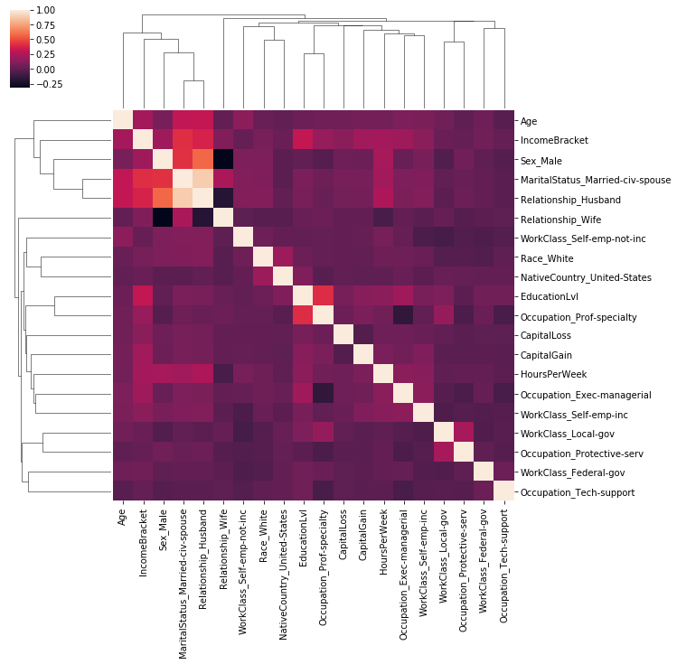

```python
#clustermap of top 20 related features
%matplotlib inline
sns.clustermap(top20corr,
            xticklabels=top20corr.columns.values,
            yticklabels=top20corr.columns.values)
```

### b. Trends in Data

We will plot a graphical figures for each of the top 3 related features: MaritalStatus_Married-civ-spouse, Relationship_Husband and EducationLvl.

#### i) Married-civ-spouse vs IncomeBracket

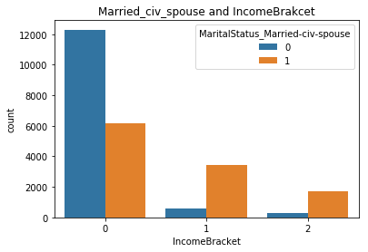

```python
%matplotlib inline
# Plot the countplot of MaritalStatus_Married-civ-spourse vs IncomeBracket
sns.countplot(data= cleaned_income_training, hue="MaritalStatus_Married-civ-spouse", x="IncomeBracket").set_title('Married_civ_spouse and IncomeBrakcet')

# Display the plot
plt.show()
```

From the plot, we can discover that, as the income bracket grows, the number of individuals that are married-civ-spouse becomes much higher than that of individuals with other marital-status. This indicates that the majority of high income people has marital status of married-civ-spouse. Thus the 'married-civ-spouse' feature can be useful to help classify whether an individual has income of 50k-100k or above 100k.

#### ii) Relationship_Husband vs IncomeBracket

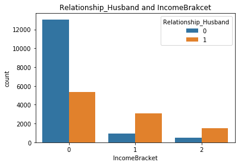

```python
%matplotlib inline
# Plot the countplot of Relationship_Husband vs IncomeBracket
sns.countplot(data= cleaned_income_training, hue="Relationship_Husband", x="IncomeBracket").set_title('Relationship_Husband and IncomeBrakcet')

# Display the plot
plt.show()
```

'Relationship_Husband' is similar to 'Married_civ_spouse' as both indicate whether the individual is married or not. However, 'Relationship_Husband' also indicates the gender of the individual. The plot shows us that most high income individuals are male and married. Thus the 'Relationship_Husband' feature can also be useful to help classify whether an individual has income of 50k-100k or above 100k.

#### iii) EducationLvl vs IncomeBracket

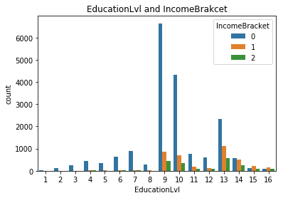

```python
%matplotlib inline
# Plot the countplot of EducationLvl vs IncomeBracket
sns.countplot(data= cleaned_income_training, hue="IncomeBracket", x="EducationLvl").set_title('EducationLvl and IncomeBrakcet')

# Display the plot
plt.show()
```

This plot indicates that most individuals with education level lower than 9 has income lower than 50k, very small portion of them has income higher than 50k. Large portion of people with education level of 15-16 has income 50k-10k. Thus, this feature is help in classifying whether an individual has income of lower than 50k or higher.

## Part 3: Feature Selection

Dummy variables were created additionally for one-hot labeling based on the original features of the dataset. This type of feature engineering is called feature representation. Feature engineering is a usefull tool in machine learning because it creates new features from existing ones and it is one of the most effective ways to improve model performance. Through feature engineering, we can isolate key information, highlight patterns and bring in domain expertise.

Based on the original features, we can also add a new feature called 'Invest' which indicates whether an individual do investments. This can be generated based on the 'CapitalGain' and 'CapitalLoss' features. If an individual has 'CapitalGain' or 'CapitalLoss' other than 0 then he/she has 'Invest' of 1, else he/she has 'Invest' of 0. This type of feature engineering is called indicator variables which involves using indicator variables to isolate key information.

```python
cleaned_income_training['Invest'] = np.where((cleaned_income_training['CapitalGain'] > 0) | (cleaned_income_training['CapitalLoss'] > 0), 1, 0)
cleaned_income_training[['CapitalGain','CapitalLoss','Invest']].head(10)
```

|  | CapitalGain | CapitalLoss | Invest |
| --- | --- | --- | --- |
| 0 | 0 | 0 | 0 |
| 1 | 0 | 0 | 0 |
| 2 | 0 | 0 | 0 |
| 3 | 0 | 0 | 0 |
| 4 | 2228 | 0 | 1 |
| 5 | 0 | 1741 | 1 |
| 6 | 0 | 0 | 0 |
| 7 | 0 | 0 | 0 |
| 8 | 0 | 1590 | 1 |
| 9 | 0 | 0 | 0 |

```python
# get new correlation table
corr2 = cleaned_income_training.corr()
SortedCorr2 = corr2.sort_values(by=['IncomeBracket'], ascending=False)
SortedCorr2['IncomeBracket'].head(20)
```

```
IncomeBracket                       1.000000
MaritalStatus_Married-civ-spouse    0.419146
Relationship_Husband                0.378773
EducationLvl                        0.312047
Invest                              0.285643
HoursPerWeek                        0.216781
Age                                 0.215345
CapitalGain                         0.206740
Sex_Male                            0.203177
Occupation_Exec-managerial          0.198241
Occupation_Prof-specialty           0.179840
CapitalLoss                         0.138674
WorkClass_Self-emp-inc              0.134744
Relationship_Wife                   0.110242
Race_White                          0.080600
WorkClass_Federal-gov               0.065369
WorkClass_Local-gov                 0.037045
NativeCountry_United-States         0.036259
Occupation_Protective-serv          0.026735
WorkClass_Self-emp-not-inc          0.026040
Name: IncomeBracket, dtype: float64
```

As 'Invest' is among the top 5 related features, we will include it in the training data.

```python
#prepare training data for models
X = pd.DataFrame({
    'MaritalStatus_Married-civ-spouse' : cleaned_income_training['MaritalStatus_Married-civ-spouse'],
    'Relationship_Husband' : cleaned_income_training['Relationship_Husband'],
    'EducationLvl' : cleaned_income_training['EducationLvl'],
    'Invest' : cleaned_income_training['Invest'],
    'HoursPerWeek' : cleaned_income_training['HoursPerWeek'],
    'Age' : cleaned_income_training['Age'],
    'CapitalGain' : cleaned_income_training['CapitalGain'],
    'Sex_Male' : cleaned_income_training['Sex_Male'],
    'Occupation_Exec-managerial' : cleaned_income_training['Occupation_Exec-managerial'],
    'Occupation_Prof-specialty' : cleaned_income_training['Occupation_Prof-specialty'],
    'CapitalLoss' : cleaned_income_training['CapitalLoss'],
    'WorkClass_Self-emp-inc': cleaned_income_training['WorkClass_Self-emp-inc'],
    'Relationship_Wife': cleaned_income_training['Relationship_Wife'],
})
y = pd.DataFrame({
    'IncomeBracket': cleaned_income_training['IncomeBracket']
})
```

## Part 4: Model Implementation

We write run_kforld() that will be used for cross-validation, and plot_learning_curve() that will be used for plotting learning curves.

```python
def run_kfold(classifier):

    #run KFold with 10 folds on the 891 records in the training_data
    kf = KFold(len(X.values), n_folds=10)

    #initiate the outcome and counter
    train_outcomes = []
    test_outcomes = []
    fold = 0

    #get the train and test index from the KFold records
    for train_index, test_index in kf:
        fold += 1
        #get the training input and testing input from KFold records
        X_train, X_test = X.values[train_index], X.values[test_index]
        #get the training output and testing output from KFold records
        y_train, y_test = y.values[train_index].ravel(), y.values[test_index].ravel()


        #find out the cross relationship between the training input and output
        classifier.fit(X_train, y_train)
        #predict the training result using the model we just trained before
        train_predictions = classifier.predict(X_train)
        #predict the testing result using the model we jsut trained before
        test_predictions = classifier.predict(X_test)

        #compare the train set values and get the accuracy
        train_accuracy = accuracy_score(y_train, train_predictions)
        #compare the test set values and get the accuracy
        test_accuracy = accuracy_score(y_test, test_predictions)
        #put the training accuracy into the outcome
        train_outcomes.append(train_accuracy)
        #put the training accuracy in the outcome
        test_outcomes.append(test_accuracy)
        print("Fold {0} training and testing accuracy: {1}, {2}".format(fold, train_accuracy, test_accuracy))

    #calculate the mean train value
    mean_train_outcome = np.mean(train_outcomes)
    #calculate the mean test value
    mean_test_outcome = np.mean(test_outcomes)
    print("Mean Training and Testing Accuracy: {0}, {1}".format(mean_train_outcome, mean_test_outcome))
    return mean_train_outcome, mean_test_outcome
```

```python
def plot_learning_curve(estimator, title, X, y, ylim=None, cv=None, n_jobs=1,\
                        train_sizes=np.linspace(.1, 1.0, 5), scoring='accuracy'):

    plt.figure(figsize=(10,6))
    plt.title(title)

    if ylim is not None:
        plt.ylim(*ylim)

    plt.xlabel("Training examples")
    plt.ylabel(scoring)

    #get training score and test score from learning curve
    train_sizes, train_scores, test_scores = learning_curve(estimator, X, y, cv=cv, scoring=scoring, n_jobs=n_jobs, train_sizes=train_sizes)
    train_scores_mean = np.mean(train_scores, axis=1)
    train_scores_std = np.std(train_scores, axis=1)
    test_scores_mean = np.mean(test_scores, axis=1)
    test_scores_std = np.std(test_scores, axis=1)

    plt.grid()

    plt.fill_between(train_sizes, train_scores_mean - train_scores_std,\
                     train_scores_mean + train_scores_std, alpha=0.1, \
                     color="r")
    plt.fill_between(train_sizes, test_scores_mean - test_scores_std,\
                     test_scores_mean + test_scores_std, alpha=0.1, color="g")

    plt.plot(train_sizes, train_scores_mean, 'o-', color="r",label="Training score")
    plt.plot(train_sizes, test_scores_mean, 'o-', color="g", label="Cross-validation score")
    plt.legend(loc="best")

    return plt
```

### a. Decision Tree

Decision Tree is a classification algorithm that produces rules using attributes data that can be used to classify data.

Pros: Decision Tree is easy to understand and visualize, it can handle both numerical and categorical data. Cons: Decision tree can create complex trees that do not generalise well, and small variations in the data might result in a completely different tree being generated.

I choose this algorithm because it is efficient and easy to understand.

```python
dtree_no_tune = DecisionTreeClassifier()
dtree_no_tune
```

```
DecisionTreeClassifier(class_weight=None, criterion='gini', max_depth=None,
            max_features=None, max_leaf_nodes=None,
            min_impurity_decrease=0.0, min_impurity_split=None,
            min_samples_leaf=1, min_samples_split=2,
            min_weight_fraction_leaf=0.0, presort=False, random_state=None,
            splitter='best')
```

```python
dtree_no_tune_mean_train, dtree_no_tune_mean_test = run_kfold(dtree_no_tune)
```

```
Fold 1 training and testing accuracy: 0.9322959322959323, 0.7539909946786738
Fold 2 training and testing accuracy: 0.9302516038036307, 0.7657657657657657
Fold 3 training and testing accuracy: 0.9314345511624733, 0.7596232596232596
Fold 4 training and testing accuracy: 0.9310250693844124, 0.762080262080262
Fold 5 training and testing accuracy: 0.92988762000091, 0.7755937755937756
Fold 6 training and testing accuracy: 0.9311615633104326, 0.7665847665847666
Fold 7 training and testing accuracy: 0.9308885754583921, 0.7645372645372646
Fold 8 training and testing accuracy: 0.9323900086446153, 0.7514332514332515
Fold 9 training and testing accuracy: 0.9313890531871332, 0.7694512694512694
Fold 10 training and testing accuracy: 0.9318440329405342, 0.7547092547092548
Mean Training and Testing Accuracy: 0.9312568010188466, 0.7623769864457544
```

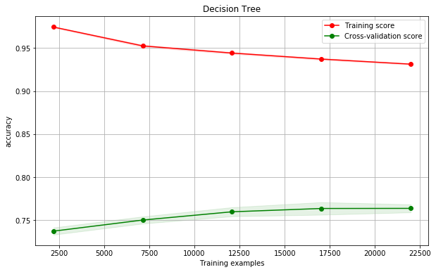

```python
%matplotlib inline
plot_learning_curve(dtree_no_tune, 'Decision Tree', X.values, y.values.ravel(), cv=10);
```

### b. Random Forest

Random forest classifier fits a number of decision trees on various sub-samples of datasets and uses average to improve the model prediction accuracy and controls over-fitting.

Pros: Decrease in overfitting, usually more accurate than decision trees. Cons: Slow real time prediction, algorithm is complex and difficult to implement.

I choose random forest classifier because I want to see if it is more accurate than decision tree model in this problem.

```python
clf_no_tune = RandomForestClassifier()
clf_no_tune
```

```
RandomForestClassifier(bootstrap=True, class_weight=None, criterion='gini',
            max_depth=None, max_features='auto', max_leaf_nodes=None,
            min_impurity_decrease=0.0, min_impurity_split=None,
            min_samples_leaf=1, min_samples_split=2,
            min_weight_fraction_leaf=0.0, n_estimators=10, n_jobs=1,
            oob_score=False, random_state=None, verbose=0,
            warm_start=False)
```

```python
clf_no_tune_mean_train, clf_no_tune_mean_test = run_kfold(clf_no_tune)
```

```
Fold 1 training and testing accuracy: 0.9225134225134225, 0.7736389684813754
Fold 2 training and testing accuracy: 0.9203785431548296, 0.782964782964783
Fold 3 training and testing accuracy: 0.921515992538332, 0.7731367731367731
Fold 4 training and testing accuracy: 0.9201965512534692, 0.7948402948402948
Fold 5 training and testing accuracy: 0.919605077574048, 0.7886977886977887
Fold 6 training and testing accuracy: 0.9209245188589108, 0.7796887796887797
Fold 7 training and testing accuracy: 0.9197870694754083, 0.7813267813267813
Fold 8 training and testing accuracy: 0.9211975067109514, 0.7735462735462736
Fold 9 training and testing accuracy: 0.9218799763410528, 0.780917280917281
Fold 10 training and testing accuracy: 0.9204695391055098, 0.7764127764127764
Mean Training and Testing Accuracy: 0.9208468197525933, 0.7805170500012907
```

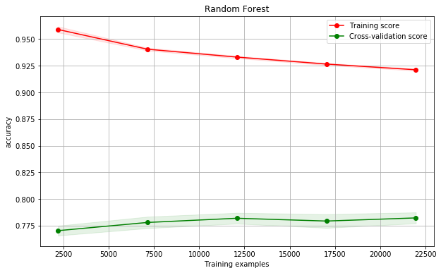

```python
%matplotlib inline
plot_learning_curve(clf_no_tune, 'Random Forest', X.values, y.values.ravel(), cv=10);
```

### c. K-Nearest Neighbours

K-Nearest Neighbours classification is computed from a simple majority vote of the k nearest neighbours of each point.

Pros: The algorithm is simple to implement, robust to noisy training data, and effective if training data is large. Cons: The number K has to be determined and the computation cost is high as it needs to computer the distance of each instance to all the training samples.

I choose this model because we have large training data and it is an effective algorithm when training data is large.

```python
knn_no_tune = KNeighborsClassifier()
knn_no_tune
```

```
KNeighborsClassifier(algorithm='auto', leaf_size=30, metric='minkowski',
           metric_params=None, n_jobs=1, n_neighbors=5, p=2,
           weights='uniform')
```

```python
knn_no_tune_mean_train, knn_no_tune_mean_test = run_kfold(knn_no_tune)
```

```
Fold 1 training and testing accuracy: 0.8396578396578397, 0.7863282848956201
Fold 2 training and testing accuracy: 0.8385731834933345, 0.7911547911547911
Fold 3 training and testing accuracy: 0.8410755721370399, 0.7886977886977887
Fold 4 training and testing accuracy: 0.8393011510987761, 0.800982800982801
Fold 5 training and testing accuracy: 0.8389826652713954, 0.8022113022113022
Fold 6 training and testing accuracy: 0.8391191591974158, 0.7862407862407862
Fold 7 training and testing accuracy: 0.8384821875426544, 0.7964782964782965
Fold 8 training and testing accuracy: 0.8394376450247963, 0.7878787878787878
Fold 9 training and testing accuracy: 0.8396196369261568, 0.7993447993447993
Fold 10 training and testing accuracy: 0.8403476045315983, 0.7915642915642915
Mean Training and Testing Accuracy: 0.8394596644881007, 0.7930881929449265
```

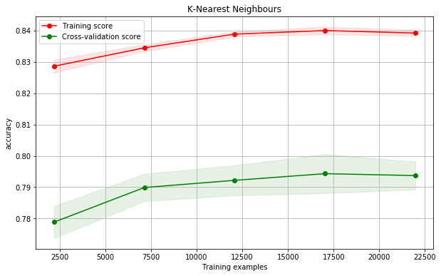

```python
%matplotlib inline
plot_learning_curve(knn_no_tune, 'K-Nearest Neighbours', X.values, y.values.ravel(), cv=10);
```

### d. Gradient Boosting

Gradient Boosting uses residual function as graident of the learning model at iteration. It produces a prediction model in the form of an ensemble of weak prediction models, typically decision trees. It uses boosting which is an ensemble technique in which the predictors are not made independently, but sequentially.

Pros: It minimize residuals on training data, reduce bias and variance. Cons: Training process can require a lot of computation. Hard to interpret. Overfitting can occur.

I choose this algorithm because it can achieve excellent accuracy and reduce bias. I also want to see if gradient boosted trees actually perform better than a random forest.

```python
gb_no_tune = GradientBoostingClassifier()
gb_no_tune
```

```
GradientBoostingClassifier(criterion='friedman_mse', init=None,
              learning_rate=0.1, loss='deviance', max_depth=3,
              max_features=None, max_leaf_nodes=None,
              min_impurity_decrease=0.0, min_impurity_split=None,
              min_samples_leaf=1, min_samples_split=2,
              min_weight_fraction_leaf=0.0, n_estimators=100,
              presort='auto', random_state=None, subsample=1.0, verbose=0,
              warm_start=False)
```

```python
gb_no_tune_mean_train, gb_no_tune_mean_test = run_kfold(gb_no_tune)
```

```
Fold 1 training and testing accuracy: 0.8196833196833196, 0.809250920998772
Fold 2 training and testing accuracy: 0.8196005277765139, 0.8104013104013104
Fold 3 training and testing accuracy: 0.8191000500477729, 0.8128583128583129
Fold 4 training and testing accuracy: 0.8165976614040675, 0.8300573300573301
Fold 5 training and testing accuracy: 0.8190090540970927, 0.8218673218673219
Fold 6 training and testing accuracy: 0.8194185358751536, 0.8132678132678133
Fold 7 training and testing accuracy: 0.8195095318258337, 0.8149058149058149
Fold 8 training and testing accuracy: 0.8195095318258337, 0.8054873054873055
Fold 9 training and testing accuracy: 0.819191045998453, 0.816953316953317
Fold 10 training and testing accuracy: 0.820101005505255, 0.8046683046683046
Mean Training and Testing Accuracy: 0.8191720264039295, 0.8139717751465602
```

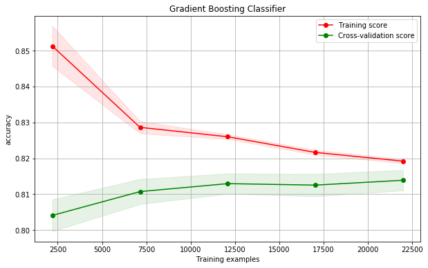

```python
%matplotlib inline
plot_learning_curve(gb_no_tune, 'Gradient Boosting Classifier', X.values, y.values.ravel(), cv=10);
```

### e. Discussion

Mean Accuracy Table:

```python
accuracyTable = pd.DataFrame(columns = ['model','training', 'testing', 'difference'])
accuracyTable['model'] = ['Decision Tree', 'Random Forest', 'K-Nearest Neighbours', 'Gradient Boosting']
accuracyTable['training'] = [dtree_no_tune_mean_train, clf_no_tune_mean_train, knn_no_tune_mean_train, gb_no_tune_mean_train]
accuracyTable['testing'] = [dtree_no_tune_mean_test, clf_no_tune_mean_test, knn_no_tune_mean_test, gb_no_tune_mean_test]
accuracyTable['difference'] = accuracyTable['training'] - accuracyTable['testing']
accuracyTable
```

|  | model | training | testing | difference |
| --- | --- | --- | --- | --- |
| 0 | Decision Tree | 0.931257 | 0.762377 | 0.168880 |
| 1 | Random Forest | 0.920847 | 0.780517 | 0.140330 |
| 2 | K-Nearest Neighbours | 0.839460 | 0.793088 | 0.046371 |
| 3 | Gradient Boosting | 0.819172 | 0.813972 | 0.005200 |

## Part 5: Model Tuning

The function below will be used to plot confusion matrix.

```python
def plot_confusion_matrix(cm, classes,
                          normalize=False,
                          title='Confusion matrix',
                          cmap=plt.cm.Blues):

    #normalize confusion matrix data
    cm = cm.astype('float') / cm.sum(axis=1)[:, np.newaxis]
    print("Normalized confusion matrix")

    plt.imshow(cm, interpolation='nearest', cmap=cmap)
    plt.title(title)
    plt.colorbar()
    tick_marks = np.arange(len(classes))
    plt.xticks(tick_marks, classes, rotation=45)
    plt.yticks(tick_marks, classes)

    fmt = '.2f' if normalize else 'd'
    thresh = cm.max() / 2.
    for i, j in itertools.product(range(cm.shape[0]), range(cm.shape[1])):
        plt.text(j, i, format(cm[i, j], fmt),
                 horizontalalignment="center",
                 color="white" if cm[i, j] > thresh else "black")

    plt.tight_layout()
    plt.ylabel('True label')
    plt.xlabel('Predicted label')
```

### a. Decision Tree

```python
dtree = DecisionTreeClassifier()

dtree_param_grid = {"criterion": ["gini", "entropy"],
              "min_samples_split": [2, 10, 20],
              "max_depth": [None, 2, 5, 10],
              "min_samples_leaf": [1, 5, 10],
              "max_leaf_nodes": [None, 5, 10, 20],
              }

# make_scorer returns a callable object that scores an estimator’s output.
#We are using accuracy_score for comparing different parameter combinations.
acc_scorer = make_scorer(accuracy_score)

# Run the grid search for the decision tree
dtree_grid_obj = GridSearchCV(dtree, dtree_param_grid, scoring=acc_scorer)
dtree_grid_obj = dtree_grid_obj.fit(X.values, y.values.ravel())

# Set our classifier, dtree, to the have the best combination of parameters
dtree = dtree_grid_obj.best_estimator_

dtree
```

```
DecisionTreeClassifier(class_weight=None, criterion='gini', max_depth=None,
            max_features=None, max_leaf_nodes=20,
            min_impurity_decrease=0.0, min_impurity_split=None,
            min_samples_leaf=1, min_samples_split=2,
            min_weight_fraction_leaf=0.0, presort=False, random_state=None,
            splitter='best')
```

```python
dtree_mean_train, dtree_mean_test = run_kfold(dtree)
```

```
Fold 1 training and testing accuracy: 0.8104923104923105, 0.8072042570609906
Fold 2 training and testing accuracy: 0.8094089813003321, 0.8087633087633087
Fold 3 training and testing accuracy: 0.8094544792756723, 0.800982800982801
Fold 4 training and testing accuracy: 0.8077710541880886, 0.8165438165438166
Fold 5 training and testing accuracy: 0.8103189408071341, 0.8181818181818182
Fold 6 training and testing accuracy: 0.8104099367578143, 0.8083538083538083
Fold 7 training and testing accuracy: 0.8101369489057737, 0.803030303030303
Fold 8 training and testing accuracy: 0.812593839574139, 0.7985257985257985
Fold 9 training and testing accuracy: 0.8094544792756723, 0.8132678132678133
Fold 10 training and testing accuracy: 0.8113653942399564, 0.7964782964782965
Mean Training and Testing Accuracy: 0.8101406364816894, 0.8071332021188755
```

```python
#get confusion matrix
dtree_y_pred = cross_val_predict(dtree,X.values,y.values.ravel(),cv=10)
dtree_conf_mat = confusion_matrix(y.values.ravel(),dtree_y_pred)
```

```
Normalized confusion matrix
```

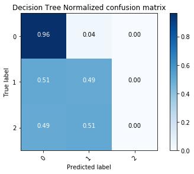

```python
%matplotlib inline
# Plot normalized confusion matrix
plt.figure()
plot_confusion_matrix(dtree_conf_mat, classes=[0,1,2], normalize=True,
                      title='Decision Tree Normalized confusion matrix')

plt.show()
```

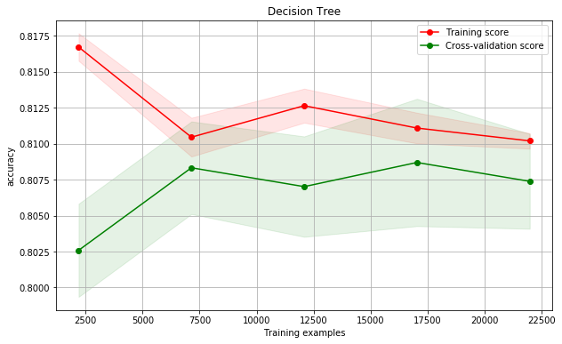

```python
%matplotlib inline
plot_learning_curve(dtree, 'Decision Tree', X.values, y.values.ravel(), cv=10);
```

### b. Random Forest

```python
# Choose the type of classifier.
clf = RandomForestClassifier()
# Choose some parameter combinations to try
parameters = {'n_estimators': [4, 6, 9, 10, 15, 20, 25, 30],
              'max_features': ['log2', 'sqrt','auto'],
              'criterion': ['entropy', 'gini'],
              'max_depth': [2, 3, 5, 10],
              'min_samples_split': [2, 3, 5],
              'min_samples_leaf': [1,5,8]
             }

# make_scorer returns a callable object that scores an estimator’s output.
#We are using accuracy_score for comparing different parameter combinations.
acc_scorer = make_scorer(accuracy_score)

# Run the grid search for the Random Forest classifier
clf_grid_obj = GridSearchCV(clf, parameters, scoring=acc_scorer)
clf_grid_obj = clf_grid_obj.fit(X.values, y.values.ravel())

# Set our classifier, clf, to the have the best combination of parameters
clf = clf_grid_obj.best_estimator_

clf
```

```
RandomForestClassifier(bootstrap=True, class_weight=None, criterion='entropy',
            max_depth=10, max_features='sqrt', max_leaf_nodes=None,
            min_impurity_decrease=0.0, min_impurity_split=None,
            min_samples_leaf=5, min_samples_split=5,
            min_weight_fraction_leaf=0.0, n_estimators=30, n_jobs=1,
            oob_score=False, random_state=None, verbose=0,
            warm_start=False)
```

```python
clf_mean_train, clf_mean_test = run_kfold(clf)
```

```
Fold 1 training and testing accuracy: 0.8191373191373191, 0.8108882521489972
Fold 2 training and testing accuracy: 0.819191045998453, 0.8087633087633087
Fold 3 training and testing accuracy: 0.8199645115792348, 0.8079443079443079
Fold 4 training and testing accuracy: 0.8183720824423313, 0.8263718263718264
Fold 5 training and testing accuracy: 0.8176441148368898, 0.816953316953317
Fold 6 training and testing accuracy: 0.8173256290095091, 0.814086814086814
Fold 7 training and testing accuracy: 0.8181445925656309, 0.8079443079443079
Fold 8 training and testing accuracy: 0.8194640338504936, 0.8063063063063063
Fold 9 training and testing accuracy: 0.8188725601710724, 0.8161343161343161
Fold 10 training and testing accuracy: 0.8182355885163111, 0.8046683046683046
Mean Training and Testing Accuracy: 0.8186351478107244, 0.8120061061321806
```

```python
#get confusion matrix
clf_y_pred = cross_val_predict(clf,X.values,y.values.ravel(),cv=10)
clf_conf_mat = confusion_matrix(y.values.ravel(),clf_y_pred)
```

```
Normalized confusion matrix
```

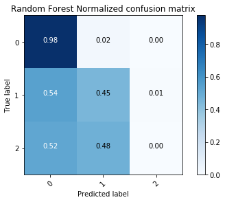

```python
%matplotlib inline
# Plot normalized confusion matrix
plt.figure()
plot_confusion_matrix(clf_conf_mat, classes=[0,1,2], normalize=True,
                      title='Random Forest Normalized confusion matrix')

plt.show()
```

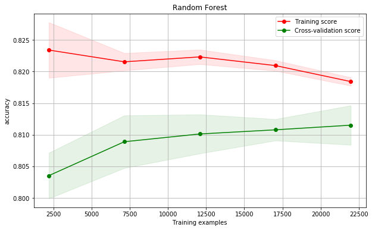

```python
%matplotlib inline
plot_learning_curve(clf, 'Random Forest', X.values, y.values.ravel(), cv=10);
```

### c. K-Nearest Neighbours

```python
knn = KNeighborsClassifier()
# define the parameter values that should be searched
k_range = list(range(1, 31))
knn_param_grid = dict(n_neighbors=k_range)

acc_scorer = make_scorer(accuracy_score)
knn_grid_obj = GridSearchCV(knn, knn_param_grid, cv=10, scoring=acc_scorer)
knn_grid_obj = knn_grid_obj.fit(X.values, y.values.ravel())

# Set our classifier, knn, to the have the best combination of parameters
knn = knn_grid_obj.best_estimator_

knn
```

```
KNeighborsClassifier(algorithm='auto', leaf_size=30, metric='minkowski',
           metric_params=None, n_jobs=1, n_neighbors=19, p=2,
           weights='uniform')
```

```python
knn_mean_train, knn_mean_test = run_kfold(knn)
```

```
Fold 1 training and testing accuracy: 0.8184548184548185, 0.8014735980352026
Fold 2 training and testing accuracy: 0.8179171026889304, 0.7993447993447993
Fold 3 training and testing accuracy: 0.8173711269848492, 0.8018018018018018
Fold 4 training and testing accuracy: 0.8154602120205651, 0.8116298116298116
Fold 5 training and testing accuracy: 0.8159606897493061, 0.814086814086814
Fold 6 training and testing accuracy: 0.8176896128122298, 0.8005733005733006
Fold 7 training and testing accuracy: 0.8181900905409709, 0.8050778050778051
Fold 8 training and testing accuracy: 0.8181445925656309, 0.800982800982801
Fold 9 training and testing accuracy: 0.8173711269848492, 0.8108108108108109
Fold 10 training and testing accuracy: 0.8176896128122298, 0.8001638001638002
Mean Training and Testing Accuracy: 0.817424898561438, 0.8045945342506947
```

```python
#get confusion matrix
knn_y_pred = cross_val_predict(knn,X.values,y.values.ravel(),cv=10)
knn_conf_mat = confusion_matrix(y.values.ravel(),knn_y_pred)
```

```
Normalized confusion matrix
```

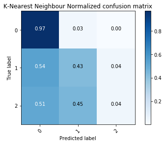

```python
%matplotlib inline
# Plot normalized confusion matrix
plt.figure()
plot_confusion_matrix(knn_conf_mat, classes=[0,1,2], normalize=True,
                      title='K-Nearest Neighbour Normalized confusion matrix')

plt.show()
```

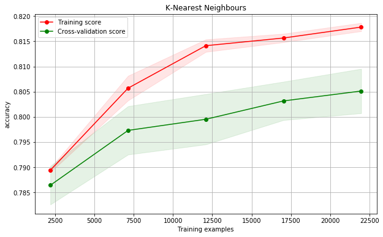

```python
%matplotlib inline
plot_learning_curve(knn, 'K-Nearest Neighbours', X.values, y.values.ravel(), cv=10);
```

### d. Gradient Boosting

```python
gb_grid_params = {'learning_rate': [0.1, 0.01],
              'max_depth': [4, 6],
              'n_estimators':[100, 1000],
              'max_features': [1.0, 0.3, 0.1]
}

#import make_scorer to calculate accuracy classification score
acc_scorer = make_scorer(accuracy_score)

gb = GradientBoostingClassifier()
gb_grid_obj = GridSearchCV(gb, gb_grid_params, cv=10, scoring=acc_scorer)
#passing it to fit method
gb_grid_obj = gb_grid_obj.fit(X.values, y.values.ravel())
#passing to estimator which can give us the highest score
gb = gb_grid_obj.best_estimator_

gb
```

```
GradientBoostingClassifier(criterion='friedman_mse', init=None,
              learning_rate=0.01, loss='deviance', max_depth=4,
              max_features=1.0, max_leaf_nodes=None,
              min_impurity_decrease=0.0, min_impurity_split=None,
              min_samples_leaf=1, min_samples_split=2,
              min_weight_fraction_leaf=0.0, n_estimators=1000,
              presort='auto', random_state=None, subsample=1.0, verbose=0,
              warm_start=False)
```

```python
gb_mean_train, gb_mean_test = run_kfold(gb)
```

```
Fold 1 training and testing accuracy: 0.8257803257803258, 0.8096602537863283
Fold 2 training and testing accuracy: 0.8273806815596706, 0.8087633087633087
Fold 3 training and testing accuracy: 0.8254242686200464, 0.8095823095823096
Fold 4 training and testing accuracy: 0.8245143091132444, 0.8296478296478297
Fold 5 training and testing accuracy: 0.8250602848173256, 0.8222768222768223
Fold 6 training and testing accuracy: 0.8262432321761681, 0.8132678132678133
Fold 7 training and testing accuracy: 0.8257427544474271, 0.814086814086814
Fold 8 training and testing accuracy: 0.8281541471404522, 0.8063063063063063
Fold 9 training and testing accuracy: 0.8262887301515083, 0.8149058149058149
Fold 10 training and testing accuracy: 0.8267437099049092, 0.8071253071253072
Mean Training and Testing Accuracy: 0.8261332443711078, 0.8135622579748654
```

```python
#get confusion matrix
gb_y_pred = cross_val_predict(gb,X.values,y.values.ravel(),cv=10)
gb_conf_mat = confusion_matrix(y.values.ravel(), gb_y_pred)
```

```
Normalized confusion matrix
```

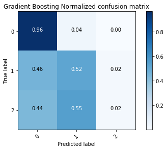

```python
%matplotlib inline
# Plot normalized confusion matrix
plt.figure()
plot_confusion_matrix(gb_conf_mat, classes=[0,1,2], normalize=True,
                      title='Gradient Boosting Normalized confusion matrix')

plt.show()
```

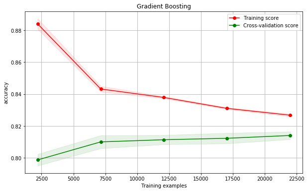

```python
%matplotlib inline
plot_learning_curve(gb, 'Gradient Boosting', X.values, y.values.ravel(), cv=10);
```

### e. Discussion

```python
tuned_accuracyTable = pd.DataFrame(columns = ['model','training', 'testing', 'difference'])
tuned_accuracyTable['model'] = ['Decision Tree', 'Random Forest', 'K-Nearest Neighbours', 'Gradient Boosting']
tuned_accuracyTable['training'] = [dtree_mean_train, clf_mean_train, knn_mean_train, gb_mean_train]
tuned_accuracyTable['testing'] = [dtree_mean_test, clf_mean_test, knn_mean_test, gb_mean_test]
tuned_accuracyTable['difference'] = tuned_accuracyTable['training'] - tuned_accuracyTable['testing']
tuned_accuracyTable
```

|  | model | training | testing | difference |
| --- | --- | --- | --- | --- |
| 0 | Decision Tree | 0.810141 | 0.807133 | 0.003007 |
| 1 | Random Forest | 0.818635 | 0.812006 | 0.006629 |
| 2 | K-Nearest Neighbours | 0.817425 | 0.804595 | 0.012830 |
| 3 | Gradient Boosting | 0.826133 | 0.813562 | 0.012571 |

After comparing the accuracies and TPR of the models, Gradient Boosting has the best performance among all four models. It has the highest average training and testing accuracy. It also has highest average TPR for the 3 income buckets. We can tune the gradient boosting model further using more hyperparameters but since it takes to long to run the model we will just use the current one. This algorithm repetitively leverage the patterns in residuals of the training data and strengthen a model with weak predictions and make it better.

In addition, we also observe that random forest does perform better than decision tree in terms of accuracy, and gradient boosting perform even better.

## Part 6: Testing & Discussion

We now use the gradient boosting model to make predictions on the test set.

```python
# add invest column to test data
cleaned_income_testing['Invest'] = np.where((cleaned_income_testing['CapitalGain'] > 0) | (cleaned_income_testing['CapitalLoss'] > 0), 1, 0)
```

```python
#prepare test set data for prediction
X_test = pd.DataFrame({
    'MaritalStatus_Married-civ-spouse' : cleaned_income_testing['MaritalStatus_Married-civ-spouse'],
    'Relationship_Husband' : cleaned_income_testing['Relationship_Husband'],
    'EducationLvl' : cleaned_income_testing['EducationLvl'],
    'HoursPerWeek' : cleaned_income_testing['HoursPerWeek'],
    'Invest' : cleaned_income_testing['Invest'],
    'Age' : cleaned_income_testing['Age'],
    'CapitalGain' : cleaned_income_testing['CapitalGain'],
    'Sex_Male' : cleaned_income_testing['Sex_Male'],
    'Occupation_Exec-managerial' : cleaned_income_testing['Occupation_Exec-managerial'],
    'Occupation_Prof-specialty' : cleaned_income_testing['Occupation_Prof-specialty'],
    'CapitalLoss' : cleaned_income_testing['CapitalLoss'],
    'WorkClass_Self-emp-inc': cleaned_income_testing['WorkClass_Self-emp-inc'],
    'Relationship_Wife': cleaned_income_testing['Relationship_Wife']
})
y_test = pd.DataFrame({
    'IncomeBracket': cleaned_income_testing['IncomeBracket']
})
```

```python
#predict the testing result using the model we jsut trained before
test_predictions = gb.predict(X_test.values)
test_accuracy = accuracy_score(y_test.values.ravel(), test_predictions)
```

```python
test_accuracy
```

```
0.8055851281631315
```

```python
#get confusion matrix
gb_y_test_pred = cross_val_predict(gb,X_test.values,y_test.values.ravel(),cv=10)
gb_test_conf_mat = confusion_matrix(y_test.values.ravel(), gb_y_test_pred)
```

```
Normalized confusion matrix
```

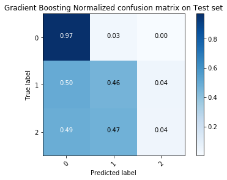

```python
%matplotlib inline
# Plot normalized confusion matrix
plt.figure()
plot_confusion_matrix(gb_test_conf_mat, classes=[0,1,2], normalize=True,
                      title='Gradient Boosting Normalized confusion matrix on Test set')

plt.show()
```

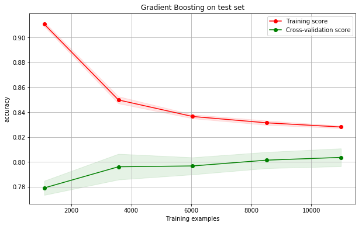

```python
%matplotlib inline
plot_learning_curve(gb, 'Gradient Boosting on test set', X_test.values, y_test.values.ravel(), cv=10);
```

```python
gb_accTable = pd.DataFrame(columns = ['training on train set',
                                      'testing on train set',
                                      'diff of train. vs test. on train set',
                                      'testing on test set',
                                      'diff of train. on train set vs test. on test set',
                                     'diff of test. on train set vs test. on test set'])
gb_accTable['training on train set'] = [gb_mean_train]
gb_accTable['testing on train set'] = [gb_mean_test]
gb_accTable['diff of train. vs test. on train set'] = gb_accTable['training on train set'] - gb_accTable['testing on train set']
gb_accTable['testing on test set'] = [test_accuracy]
gb_accTable['diff of train. on train set vs test. on test set'] = gb_accTable['training on train set'] - gb_accTable['testing on test set']
gb_accTable['diff of test. on train set vs test. on test set'] = gb_accTable['testing on train set'] - gb_accTable['testing on test set']
gb_accTable
```

|  | training on train set | testing on train set | diff of train. vs test. on train set | testing on test set | diff of train. on train set vs test. on test set | diff of test. on train set vs test. on test set |
| --- | --- | --- | --- | --- | --- | --- |
| 0 | 0.826133 | 0.813562 | 0.012571 | 0.805585 | 0.020548 | 0.007977 |

From the accuracy table we can see that, the testing accuracy of test set is 0.00797 lower than that of training set, which is not a significant difference. The TPR on income bracket 2 of the test set is lower than that of training set, but the TPR on income bracket 1 and 3 of test set is higher than that of the training set. We would say the accuracy on test set is slightly worse than that of the training set.

In term of bias-variance trade-off, the accuracy variance on test set is slightly larger than that on training set but both do not have overfitting since the difference between mean accuracy is smaller than 0.1, the distance between training score and validation score on the learning curve plots are also small when the amount of training samples gets high. The model encounters underfitting on both the training set and the test set because the validation score increases while the training score decreases on both learning curves.